# Reproducible Research: Peer Assessment 1

## Imputing missing values

Requirement: Note that there are a number of days/intervals where there are missing values (coded as NA). The presence of missing days may introduce bias into some calculations or summaries of the data. 1. Calculate and report the total number of missing values in the dataset (i.e. the total number of rows with NAs) 2. Devise a strategy for filling in all of the missing values in the dataset. The strategy does not need to be sophisticated. For example, you could use the mean/median for that day, or the mean for that 5-minute interval, etc. 3. Create a new dataset that is equal to the original dataset but with the missing data filled in. 4. Make a histogram of the total number of steps taken each day and Calculate and report the mean and median total number of steps taken per day. Do these values differ from the estimates from the first part of the assignment? What is the impact of imputing missing data on the estimates of the total daily number of steps?

Like the previous section, there comes the solution code:

```r
#Imputing missing values
##1. Calculate and report the total number of missing values in the dataset
Total_number_MV<-sum(is.na(processed_data$steps))
Total_number_MV
```

```
## [1] 2304
```

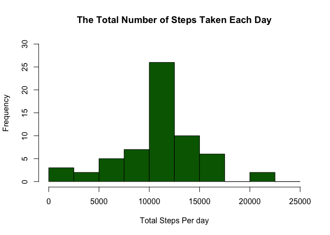

```r
##2. Devise a strategy for filling in all of the missing values in the dataset.
##The strategy does not need to be sophisticated.
New_steps<-average_number_steps$mean[
        match(activities$interval,average_number_steps$interval)
]

New_activities<-transform(activities,
                          steps=ifelse(is.na(activities$steps),
                                       yes = New_steps,
                                       no  = activities$steps))
##3. Create a new dataset
##that is equal to the original dataset
##but with the missing data filled in.
total_new<-aggregate(steps~date,New_activities,sum)
names(total_new)<-c("Date","Steps_daily")

##4. Make a histogram of the total number of steps taken each day
with(total_new,hist(Steps_daily,col = "darkgreen",
                    xlab = "Total Steps Per day",
                    ylab = "Frequency",
                    main="The Total Number of Steps Taken Each Day",
                    ylim=c(0,30),breaks=seq(0,25000,by=2500)))
```

```r
dev.copy(png,file="3.png",height=593,width=466)
```

```r
dev.off()
```

```r
##Calculate and report the mean and median total number of steps
##taken per day.
Mean_total_new<-mean(total_new$Steps_daily)
Mean_total_new
```

```
## [1] 10766.19
```

```r
Median_total_new<-median(total_new$Steps_daily)
Median_total_new
```

```
## [1] 10766.19
```

## Are there differences in activity patterns between weekdays and weekends?

The solution for these two issues is as following:

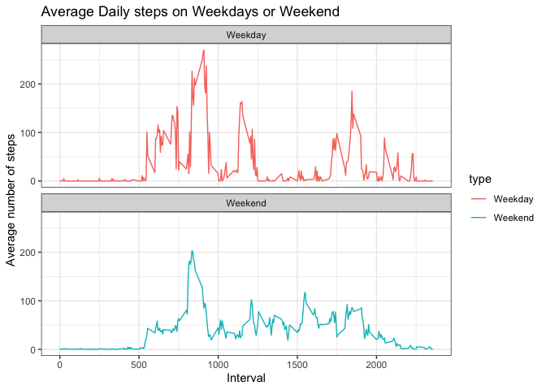

```r
##1. Create a new factor variable in the dataset with two levels – “weekday” and “weekend”
##??indicating whether a given date is a weekday or weekend day.
processed_data$type <- sapply(processed_data$week, function(x){
        if(x==c("Monday","Tuesday","Wednesday","Thursday","Friday"))
        {y <- "Weekday"}
        else{y <- "Weekend"}
        y
})

##2. Make a panel plot containing a time series plot (i.e. type = "l") of the 5-minute interval (x-axis)
##and the average number of steps taken, averaged across all weekday days or weekend days (y-axis).
##The plot should look something like the following, which was creating using simulated data:
activities_by_date <- aggregate(steps~interval + type,
                              processed_data, mean, na.rm = TRUE)
f<- ggplot(activities_by_date, aes(x = interval , y = steps, color = type))
f+geom_line() +
        labs(title = "Average Daily steps on Weekdays or Weekend", x = "Interval", y = "Average number of steps") +
        facet_wrap(~type, ncol = 1, nrow=2)+theme_bw()
```

```r
dev.copy(png,file="4.png",height=593,width=466)
```

```r
dev.off()
```